# The City of Dallas

Layne Looney

Welcome to Dallas, the place where I grew up before I came to the University of Richmond. But when I say that I grew up in Dallas, that’s not exactly true. I lived in an area of Dallas, called University Park, which is a part of Highland Park, which falls under the title of Dallas. Honestly, when people ask me where I’m from I say I’m from Dallas. It makes things easier. However the data shows some interesting patterns that involve Highland Park, and by association University Park.

Dallas can be a pretty expensive place to live. Downtown Dallas doesn’t have unlimited space, which drives prices up thanks to basic supply and demand laws. The areas around downtown Dallas aren’t exactly attractive to live in as well. There are problems in the communities, with the largest problem being high crime rates. However, Dallas has some pretty attractive housing opportunities as well, if you know where to look. There are great plots of land fifteen to thirty minutes away from downtown Dallas. Frisco, Denton, Prosper, McKinney, and Rockwall to name a few. There are also areas in Fort Worth that are worth looking into as well. The graph below deals with people who live in Dallas that are between ages eighteen to twenty four. This is expressed in a percentage. This age group is mostly comprised of students who are about to leave for college, students who are in college, and students who are just out of college. Looking at this graph

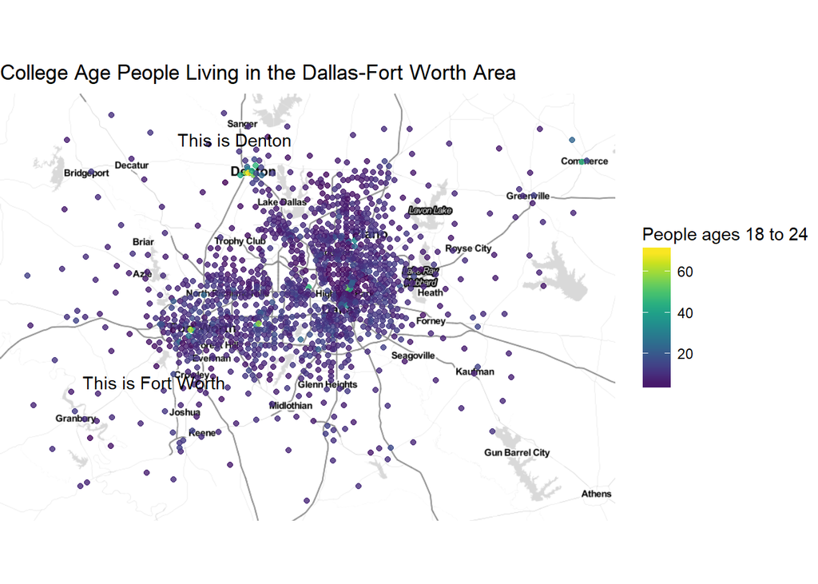

there are two main areas where there the percentage of eighteen to twenty four year olds is above 60 percent. One is in the city of Denton, with a percentage of 70.48. The other is in Fort Worth, with a percentage of 61.42. Denton has lots of open land which will allow those just out of college to find or build a house they like without paying out of their price range. While it is far from downtown Dallas, there are still many job opportunities out in that area as businesses begin to relocate to places like there and Frisco. Fort Worth is different in that there is not as much open land since it is a long established city. However it is friendly to younger individuals since it is close enough to downtown Dallas where many of the jobs are, as well as housing pricing being favorable.

But where is all the income? The most income in the Dallas-Fort Worth area is in Highland Park, which the 5th percentile of household income comes in at $1,942,990, almost two million dollars. The next cloest area is north of highland park, most likely representing preston hollow, which has 1,809,033 dollars.

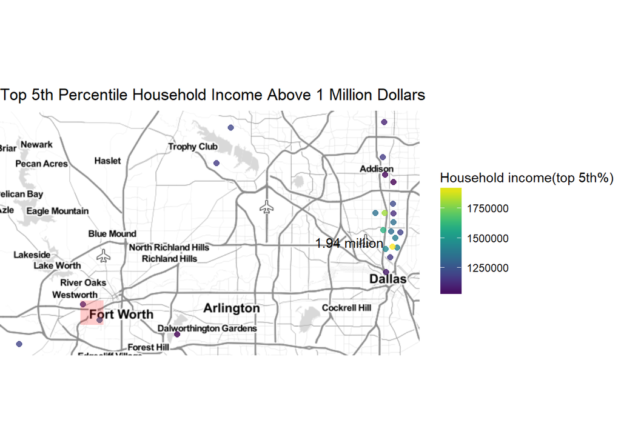

This data is also filtered so that it only shows areas that have over 1,000,000 dollars in their top 5th percentile of household income. Notice how Fort Worth only has two entries, and neither of them come close to the money that is around Dallas. Even more interesting is that Denton doesn’t have an area which fulfills this filter requirement. They aren’t even shown on the map. The places with the highest population of age college students are not places that tend to have people in the community who have a large income. This point is further reinforced by the next graph that looks at areas which have an income from 150 thousand to 999 thousand.

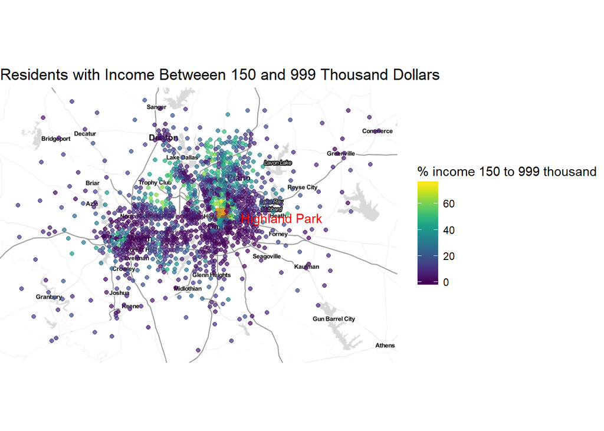

Again, the areas with the most income in the 150 to 999 thousand range is around the Highland Park area. It tends to be a well sought after area to live in, since it has such a good public school, as well as many private schools close by. It also is in a centralized location in comparison to the areas around it, with many well maintained roads and highways to commute on. There have been some comments that Highland Park is on its way to being the next Beverly Hills. A bold statement for sure, but the data shows this trend might be true. Most money is centered around Highland Park when looking at the Dallas-Fort Worth area, and with property values soaring to around a million for an average sized lot, I am interested to watch my hometown in the future to see where it goes. Who knows, maybe I’ll be able to move back home.